# Final_Exam_part2

Charls Joseph

May 23, 2019

### Part 2

#### Youtube link

https://www.youtube.com/watch?v=UZz7L3KN2u0&feature=youtu.be

Descriptive and Inferential Statistics. Provide univariate descriptive statistics and appropriate plots for the training data set. Provide a scatterplot matrix for at least two of the independent variables and the dependent variable. Derive a correlation matrix for any three quantitative variables in the dataset. Test the hypotheses that the correlations between each pairwise set of variables is 0 and provide an 80% confidence interval. Discuss the meaning of your analysis. Would you be worried about familywise error? Why or why not?

```r
house.train.df <- read.csv("house-prices-advanced-regression-techniques/train.csv")
house.train.numeric <- select_if(house.train.df, is.numeric)
dim(house.train.df)
```

```
## [1] 1460   81
```

```r
house.test.df <- read.csv("house-prices-advanced-regression-techniques/test.csv")
dim(house.test.df)
```

```
## [1] 1459   80
```

```r
summary(house.train.numeric)
```

```
##        Id           MSSubClass     LotFrontage        LotArea
##  Min.   :   1.0   Min.   : 20.0   Min.   : 21.00   Min.   :  1300
##  1st Qu.: 365.8   1st Qu.: 20.0   1st Qu.: 59.00   1st Qu.:  7554
##  Median : 730.5   Median : 50.0   Median : 69.00   Median :  9478
##  Mean   : 730.5   Mean   : 56.9   Mean   : 70.05   Mean   : 10517
##  3rd Qu.:1095.2   3rd Qu.: 70.0   3rd Qu.: 80.00   3rd Qu.: 11602
##  Max.   :1460.0   Max.   :190.0   Max.   :313.00   Max.   :215245
##                                   NA's   :259
##   OverallQual      OverallCond      YearBuilt     YearRemodAdd
##  Min.   : 1.000   Min.   :1.000   Min.   :1872   Min.   :1950
##  1st Qu.: 5.000   1st Qu.:5.000   1st Qu.:1954   1st Qu.:1967
##  Median : 6.000   Median :5.000   Median :1973   Median :1994
##  Mean   : 6.099   Mean   :5.575   Mean   :1971   Mean   :1985
##  3rd Qu.: 7.000   3rd Qu.:6.000   3rd Qu.:2000   3rd Qu.:2004
##  Max.   :10.000   Max.   :9.000   Max.   :2010   Max.   :2010
##
##    MasVnrArea       BsmtFinSF1       BsmtFinSF2        BsmtUnfSF
##  Min.   :   0.0   Min.   :   0.0   Min.   :   0.00   Min.   :   0.0
##  1st Qu.:   0.0   1st Qu.:   0.0   1st Qu.:   0.00   1st Qu.: 223.0
##  Median :   0.0   Median : 383.5   Median :   0.00   Median : 477.5
##  Mean   : 103.7   Mean   : 443.6   Mean   :  46.55   Mean   : 567.2
##  3rd Qu.: 166.0   3rd Qu.: 712.2   3rd Qu.:   0.00   3rd Qu.: 808.0
##  Max.   :1600.0   Max.   :5644.0   Max.   :1474.00   Max.   :2336.0
##  NA's   :8
##   TotalBsmtSF       X1stFlrSF      X2ndFlrSF     LowQualFinSF
##  Min.   :   0.0   Min.   : 334   Min.   :   0   Min.   :  0.000
##  1st Qu.: 795.8   1st Qu.: 882   1st Qu.:   0   1st Qu.:  0.000
##  Median : 991.5   Median :1087   Median :   0   Median :  0.000
##  Mean   :1057.4   Mean   :1163   Mean   : 347   Mean   :  5.845
##  3rd Qu.:1298.2   3rd Qu.:1391   3rd Qu.: 728   3rd Qu.:  0.000
##  Max.   :6110.0   Max.   :4692   Max.   :2065   Max.   :572.000
##
##    GrLivArea     BsmtFullBath     BsmtHalfBath        FullBath
##  Min.   : 334   Min.   :0.0000   Min.   :0.00000   Min.   :0.000
##  1st Qu.:1130   1st Qu.:0.0000   1st Qu.:0.00000   1st Qu.:1.000
##  Median :1464   Median :0.0000   Median :0.00000   Median :2.000
##  Mean   :1515   Mean   :0.4253   Mean   :0.05753   Mean   :1.565
##  3rd Qu.:1777   3rd Qu.:1.0000   3rd Qu.:0.00000   3rd Qu.:2.000
##  Max.   :5642   Max.   :3.0000   Max.   :2.00000   Max.   :3.000
##
```

[output cut: 25 more lines]

```
##  Min.   :  0.00   Min.   :  0.000   Min.   :    0.00   Min.   : 1.000
##  1st Qu.:  0.00   1st Qu.:  0.000   1st Qu.:    0.00   1st Qu.: 5.000
##  Median :  0.00   Median :  0.000   Median :    0.00   Median : 6.000
##  Mean   : 15.06   Mean   :  2.759   Mean   :   43.49   Mean   : 6.322
##  3rd Qu.:  0.00   3rd Qu.:  0.000   3rd Qu.:    0.00   3rd Qu.: 8.000
##  Max.   :480.00   Max.   :738.000   Max.   :15500.00   Max.   :12.000
##
##      YrSold       SalePrice
##  Min.   :2006   Min.   : 34900
##  1st Qu.:2007   1st Qu.:129975
##  Median :2008   Median :163000
##  Mean   :2008   Mean   :180921
##  3rd Qu.:2009   3rd Qu.:214000
##  Max.   :2010   Max.   :755000
##
```

Lets build a histogram of sales price to see the distribution. Below histogram gives you a slighly right skewed distribution.

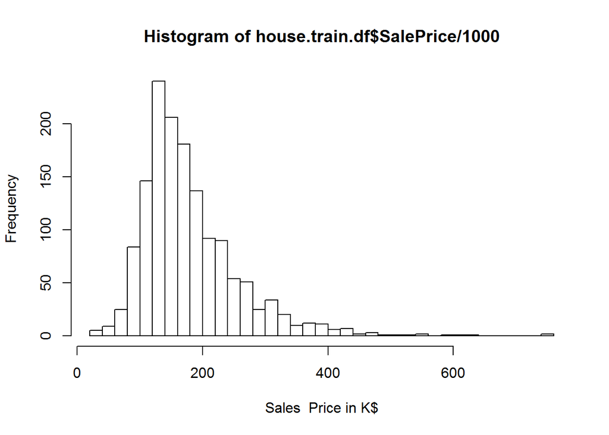

```r
hist(house.train.df$SalePrice/1000, breaks = 50, xlab = 'Sales  Price in K$')
```

Lets build couple Box-plots for some of independent qualitative variables against sales price to see if there is any relation.

#### Box-plot - Type of dwelling v/s sales Price

Observaton: Single-family Detached & Townhouse End Unit has highest mean Sales price.

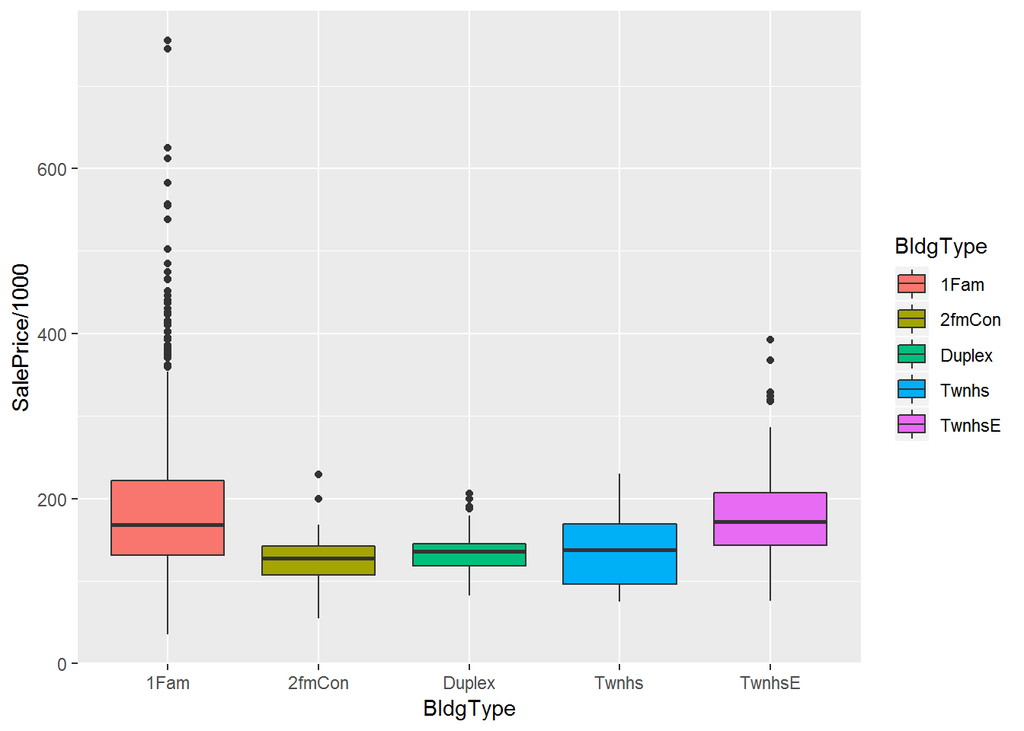

```r
ggplot(house.train.df, aes(x=BldgType, y=SalePrice/1000, fill = BldgType)) + geom_boxplot()
```

#### Box-plot - Type of foundation v/s sales Price

Observation : Poured Contrete house has highest mean sale price and Slab House has least mean sale price.

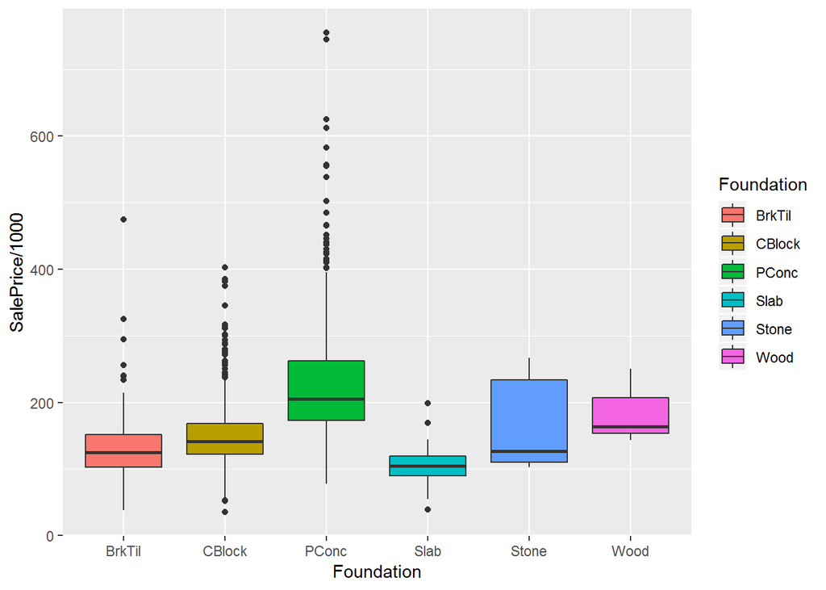

```r
ggplot(house.train.df, aes(x=Foundation, y=SalePrice/1000, fill =Foundation )) + geom_boxplot()
```

#### Box-plot - Neighborhood v/s sales Price

Observation : There are couple of neighborhoods which are highest mean sales price( e.g : Northridge Heights , Northridge , Stone Brook … )

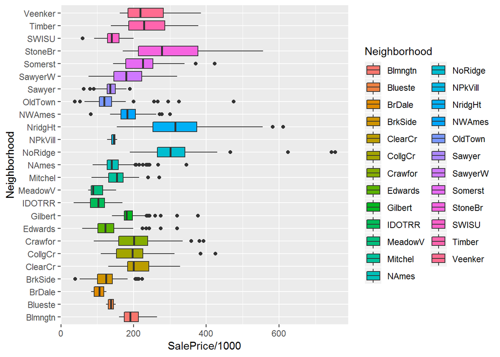

```r
ggplot(house.train.df, aes(x=Neighborhood, y=SalePrice/1000, fill=Neighborhood )) +
  geom_boxplot() + coord_flip()
```

#### Box-plot - Overall Quality v/s sales Price

This shows the exactly the relation between Quality and sales price. As quality increases, the sales price goes high which makes sense.

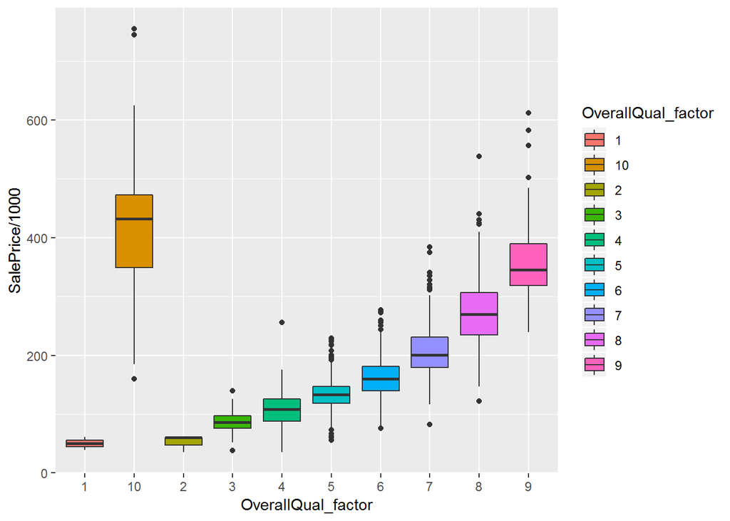

```r
house.train.df$OverallQual_factor <- as.factor(as.character(house.train.df$OverallQual))

ggplot(house.train.df, aes(x=OverallQual_factor, y=SalePrice/1000, fill = OverallQual_factor)) +
  geom_boxplot()
```

Now, lets build the correlation matrix to see the correlation between a set of variables on sales price.

### Observation: High correlation observed for below independent Variables.

#### OverallQual: Rates the overall material and finish of the house

#### GrLivArea: Above grade (ground) living area square feet

#### GarageArea: Size of garage in square feet

#### TotalBsmtSF: Total square feet of basement area

#### YearBuilt: Original construction date

#### FullBath: Full bathrooms above grade

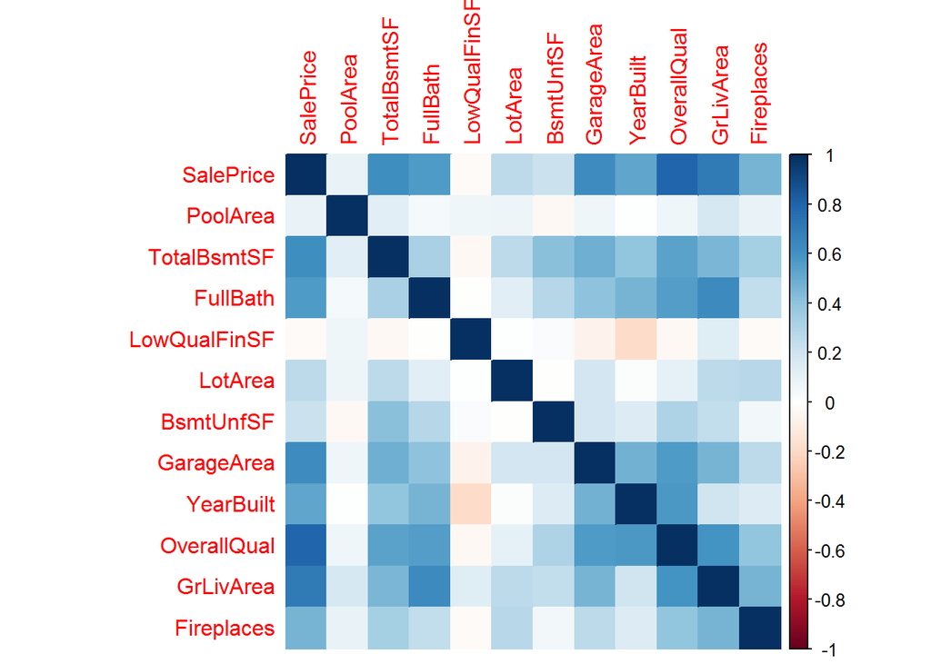

```r
corr.data<-select(house.train.df,SalePrice,PoolArea,TotalBsmtSF,FullBath,LowQualFinSF, LotArea,BsmtUnfSF,GarageArea,YearBuilt,OverallQual,FullBath,GrLivArea,Fireplaces)
corr.data<-round(cor(corr.data),4)

corrplot(corr.data,method ="color")
```

### Test the hypotheses that the correlations between each pairwise set of variables is 0 and provide an 80% confidence interval.

Lets test the hypothesis that correlation between two variable is 0 at 80% confidence interval.

#### GarageArea v/s Sales price.

The correlation is 0.6234314 and we are 80% confident that the correlaton between GarageArea and SalePrice is 0.6024756 and 0.6435283.

```r
cor.test(house.train.df$SalePrice,house.train.df$GarageArea, conf.level = 0.8)
```

```
##
##  Pearson's product-moment correlation
##
## data:  house.train.df$SalePrice and house.train.df$GarageArea
## t = 30.446, df = 1458, p-value < 2.2e-16
## alternative hypothesis: true correlation is not equal to 0
## 80 percent confidence interval:
##  0.6024756 0.6435283
## sample estimates:
##       cor
## 0.6234314
```

#### GrLivArea v/s Sales price.

The correlation is 0.7086245 and we are 80% confident that the correlaton between GrLivArea and SalePrice is 0.6915087 and 0.7249450

```r
cor.test(house.train.df$SalePrice,house.train.df$GrLivArea, conf.level = 0.8)
```

```
##
##  Pearson's product-moment correlation
##
## data:  house.train.df$SalePrice and house.train.df$GrLivArea
## t = 38.348, df = 1458, p-value < 2.2e-16
## alternative hypothesis: true correlation is not equal to 0
## 80 percent confidence interval:
##  0.6915087 0.7249450
## sample estimates:
##       cor
## 0.7086245
```

#### TotalBsmtSF v/s Sales price.

The correlation is 0.6135806 and we are 80% confident that the correlaton between TotalBsmtSF and SalePrice is 0.5922142 and 0.6340846

```r
cor.test(house.train.df$SalePrice,house.train.df$TotalBsmtSF, conf.level = 0.8)
```

```
##
##  Pearson's product-moment correlation
##
## data:  house.train.df$SalePrice and house.train.df$TotalBsmtSF
## t = 29.671, df = 1458, p-value < 2.2e-16
## alternative hypothesis: true correlation is not equal to 0
## 80 percent confidence interval:
##  0.5922142 0.6340846
## sample estimates:
##       cor
## 0.6135806
```

## Invert your correlation matrix from above. (This is known as the precision matrix and contains variance inflation factors on the diagonal.) Multiply the correlation matrix by the precision matrix, and then multiply the precision matrix by the correlation matrix. Conduct LU decomposition on the matrix.

```r
precision.matrix<-solve(corr.data)
round(precision.matrix, 4)
```

```
##              SalePrice PoolArea TotalBsmtSF FullBath LowQualFinSF LotArea
## SalePrice       4.6083   0.1249     -0.7749  -0.0021       0.0715 -0.2843
## PoolArea        0.1249   1.0568     -0.1626   0.0585      -0.0390 -0.0138
## TotalBsmtSF    -0.7749  -0.1626      2.0709   0.3476       0.0211 -0.2515
## FullBath       -0.0021   0.0585      0.3476   2.2299       0.0492 -0.0475
## LowQualFinSF    0.0715  -0.0390      0.0211   0.0492       1.0846  0.0153
## LotArea        -0.2843  -0.0138     -0.2515  -0.0475       0.0153  1.1987
## BsmtUnfSF       0.4181   0.1217     -0.6726  -0.3196      -0.0257  0.1080
## GarageArea     -0.5108   0.0191     -0.2470   0.0535       0.0628 -0.0631
## YearBuilt      -0.5782  -0.0198     -0.2843  -0.8270       0.1762  0.1354
## OverallQual    -1.7479   0.0062     -0.0272  -0.1325      -0.0406  0.3143
## GrLivArea      -1.4607  -0.2569     -0.1068  -1.3360      -0.3095 -0.0941
## Fireplaces     -0.2520  -0.0073     -0.1385   0.1416       0.0875 -0.1838
##              BsmtUnfSF GarageArea YearBuilt OverallQual GrLivArea
## SalePrice       0.4181    -0.5108   -0.5782     -1.7479   -1.4607
## PoolArea        0.1217     0.0191   -0.0198      0.0062   -0.2569
## TotalBsmtSF    -0.6726    -0.2470   -0.2843     -0.0272   -0.1068
## FullBath       -0.3196     0.0535   -0.8270     -0.1325   -1.3360
## LowQualFinSF   -0.0257     0.0628    0.1762     -0.0406   -0.3095
## LotArea         0.1080    -0.0631    0.1354      0.3143   -0.0941
## BsmtUnfSF       1.3782     0.0334    0.1729     -0.3776   -0.0566
## GarageArea      0.0334     1.8070   -0.3854     -0.1597   -0.2787
## YearBuilt       0.1729    -0.3854    2.1567     -0.6898    1.0830
## OverallQual    -0.3776    -0.1597   -0.6898      3.3030   -0.2876
## GrLivArea      -0.0566    -0.2787    1.0830     -0.2876    3.3274
## Fireplaces      0.1399     0.0870    0.0868     -0.2426   -0.4169
##              Fireplaces
## SalePrice       -0.2520
## PoolArea        -0.0073
## TotalBsmtSF     -0.1385
## FullBath         0.1416
## LowQualFinSF     0.0875
## LotArea         -0.1838
## BsmtUnfSF        0.1399
## GarageArea       0.0870
## YearBuilt        0.0868
## OverallQual     -0.2426
## GrLivArea       -0.4169
## Fireplaces       1.4279
```

```r
round(corr.data %*% precision.matrix, 4)
```

```
##              SalePrice PoolArea TotalBsmtSF FullBath LowQualFinSF LotArea
## SalePrice            1        0           0        0            0       0
## PoolArea             0        1           0        0            0       0
## TotalBsmtSF          0        0           1        0            0       0
## FullBath             0        0           0        1            0       0
## LowQualFinSF         0        0           0        0            1       0
## LotArea              0        0           0        0            0       1
## BsmtUnfSF            0        0           0        0            0       0
## GarageArea           0        0           0        0            0       0
## YearBuilt            0        0           0        0            0       0
## OverallQual          0        0           0        0            0       0
## GrLivArea            0        0           0        0            0       0
## Fireplaces           0        0           0        0            0       0
##              BsmtUnfSF GarageArea YearBuilt OverallQual GrLivArea
## SalePrice            0          0         0           0         0
## PoolArea             0          0         0           0         0
## TotalBsmtSF          0          0         0           0         0
## FullBath             0          0         0           0         0
## LowQualFinSF         0          0         0           0         0
## LotArea              0          0         0           0         0
## BsmtUnfSF            1          0         0           0         0
## GarageArea           0          1         0           0         0
## YearBuilt            0          0         1           0         0
## OverallQual          0          0         0           1         0
## GrLivArea            0          0         0           0         1
## Fireplaces           0          0         0           0         0
##              Fireplaces
## SalePrice             0
## PoolArea              0
## TotalBsmtSF           0
## FullBath              0
## LowQualFinSF          0
## LotArea               0
## BsmtUnfSF             0
## GarageArea            0
## YearBuilt             0
## OverallQual           0
## GrLivArea             0
## Fireplaces            1
```

```r
round(precision.matrix %*% corr.data, 4)
```

```
##              SalePrice PoolArea TotalBsmtSF FullBath LowQualFinSF LotArea
## SalePrice            1        0           0        0            0       0
## PoolArea             0        1           0        0            0       0
## TotalBsmtSF          0        0           1        0            0       0
## FullBath             0        0           0        1            0       0
## LowQualFinSF         0        0           0        0            1       0
## LotArea              0        0           0        0            0       1
## BsmtUnfSF            0        0           0        0            0       0
## GarageArea           0        0           0        0            0       0
## YearBuilt            0        0           0        0            0       0
## OverallQual          0        0           0        0            0       0
## GrLivArea            0        0           0        0            0       0
## Fireplaces           0        0           0        0            0       0
##              BsmtUnfSF GarageArea YearBuilt OverallQual GrLivArea
## SalePrice            0          0         0           0         0
## PoolArea             0          0         0           0         0
## TotalBsmtSF          0          0         0           0         0
## FullBath             0          0         0           0         0
## LowQualFinSF         0          0         0           0         0
## LotArea              0          0         0           0         0
## BsmtUnfSF            1          0         0           0         0
## GarageArea           0          1         0           0         0
## YearBuilt            0          0         1           0         0
## OverallQual          0          0         0           1         0
## GrLivArea            0          0         0           0         1
## Fireplaces           0          0         0           0         0
##              Fireplaces
## SalePrice             0
## PoolArea              0
## TotalBsmtSF           0
## FullBath              0
## LowQualFinSF          0
## LotArea               0
## BsmtUnfSF             0
## GarageArea            0
## YearBuilt             0
## OverallQual           0
## GrLivArea             0
## Fireplaces            1
```

Now, lets Do LU decomposition of correlation matrix

Using the LU function from my previous assignment.

```r
factorize <- function(A)
{
  if (nrow(A) == ncol(A))
  {
      size <- nrow(A)
      # Constructing a diagonal matrix. This will become the matrix L after factorization.
      L <- diag(size)
      for (i in 1:(size - 1))
      {
          for (j in (i + 1):size)
          {
              L[j, i] <- A[j, i] / A[i, i]  # building the L matrix
              A[j, ]  <- A[j, ] - L[j, i] * A[i, ] # building U matrix
          }
      }


  }
  result<-list(L,A)
  return(result)

}
```

```r
result <- factorize(corr.data)
L <- result[[1]]
U <- result[[2]]
```

Lets check multipling L and U gives back the actual correlation data. Verified that both L*U and the actual correlation matrix is same.

```r
corr.data_1 <- round(L %*% U ,4)

corr.data_1 == corr.data
```

```
##       SalePrice PoolArea TotalBsmtSF FullBath LowQualFinSF LotArea
##  [1,]      TRUE     TRUE        TRUE     TRUE         TRUE    TRUE
##  [2,]      TRUE     TRUE        TRUE     TRUE         TRUE    TRUE
##  [3,]      TRUE     TRUE        TRUE     TRUE         TRUE    TRUE
##  [4,]      TRUE     TRUE        TRUE     TRUE         TRUE    TRUE
##  [5,]      TRUE     TRUE        TRUE     TRUE         TRUE    TRUE
##  [6,]      TRUE     TRUE        TRUE     TRUE         TRUE    TRUE
##  [7,]      TRUE     TRUE        TRUE     TRUE         TRUE    TRUE
##  [8,]      TRUE     TRUE        TRUE     TRUE         TRUE    TRUE
##  [9,]      TRUE     TRUE        TRUE     TRUE         TRUE    TRUE
## [10,]      TRUE     TRUE        TRUE     TRUE         TRUE    TRUE
## [11,]      TRUE     TRUE        TRUE     TRUE         TRUE    TRUE
## [12,]      TRUE     TRUE        TRUE     TRUE         TRUE    TRUE
##       BsmtUnfSF GarageArea YearBuilt OverallQual GrLivArea Fireplaces
##  [1,]      TRUE       TRUE      TRUE        TRUE      TRUE       TRUE
##  [2,]      TRUE       TRUE      TRUE        TRUE      TRUE       TRUE
##  [3,]      TRUE       TRUE      TRUE        TRUE      TRUE       TRUE
##  [4,]      TRUE       TRUE      TRUE        TRUE      TRUE       TRUE
##  [5,]      TRUE       TRUE      TRUE        TRUE      TRUE       TRUE
##  [6,]      TRUE       TRUE      TRUE        TRUE      TRUE       TRUE
##  [7,]      TRUE       TRUE      TRUE        TRUE      TRUE       TRUE
##  [8,]      TRUE       TRUE      TRUE        TRUE      TRUE       TRUE
##  [9,]      TRUE       TRUE      TRUE        TRUE      TRUE       TRUE
## [10,]      TRUE       TRUE      TRUE        TRUE      TRUE       TRUE
## [11,]      TRUE       TRUE      TRUE        TRUE      TRUE       TRUE
## [12,]      TRUE       TRUE      TRUE        TRUE      TRUE       TRUE
```

## Feature Engineering and Selection.

As a first step, we will convert the MSSubClass column into a factor variable and dropping some columns which are having null values.

```r
library(caTools)
set.seed(123)

head(house.train.df)
```

```
##   Id MSSubClass MSZoning LotFrontage LotArea Street Alley LotShape
## 1  1         60       RL          65    8450   Pave  <NA>      Reg
## 2  2         20       RL          80    9600   Pave  <NA>      Reg
## 3  3         60       RL          68   11250   Pave  <NA>      IR1
## 4  4         70       RL          60    9550   Pave  <NA>      IR1
## 5  5         60       RL          84   14260   Pave  <NA>      IR1
## 6  6         50       RL          85   14115   Pave  <NA>      IR1
##   LandContour Utilities LotConfig LandSlope Neighborhood Condition1
## 1         Lvl    AllPub    Inside       Gtl      CollgCr       Norm
## 2         Lvl    AllPub       FR2       Gtl      Veenker      Feedr
## 3         Lvl    AllPub    Inside       Gtl      CollgCr       Norm
## 4         Lvl    AllPub    Corner       Gtl      Crawfor       Norm
## 5         Lvl    AllPub       FR2       Gtl      NoRidge       Norm
## 6         Lvl    AllPub    Inside       Gtl      Mitchel       Norm
##   Condition2 BldgType HouseStyle OverallQual OverallCond YearBuilt
```

[output cut: 76 more lines]

```r
house.train.df$MSSubClass = factor(house.train.df$MSSubClass, levels = c(20, 30, 40 , 45, 50, 60, 70, 75, 80, 85, 90, 120, 150, 160, 180, 190))


house.test.df$MSSubClass = factor(house.test.df$MSSubClass, levels = c(20, 30, 40 , 45, 50, 60, 70, 75, 80, 85, 90, 120, 150, 160, 180, 190))

house.train.df <- house.train.df[, -which(colMeans(is.na(house.train.df)) > 0)]
```

Performing a backward elimination method to filter some of the independent variables which are not significant or less related

```r
lm1 <- lm(data = house.train.df , formula = SalePrice ~ . )
summary(lm1)
```

```
##
## Call:
## lm(formula = SalePrice ~ ., data = house.train.df)
##
## Residuals:
##     Min      1Q  Median      3Q     Max
## -174317   -9455       0    8907  174317
##
## Coefficients: (5 not defined because of singularities)
##                        Estimate Std. Error t value Pr(>|t|)
## (Intercept)          -1.956e+06  1.008e+06  -1.941 0.052490 .
## Id                   -2.747e-01  1.510e+00  -0.182 0.855690
## MSSubClass30          1.872e+03  4.606e+03   0.406 0.684563
## MSSubClass40          7.951e+02  1.428e+04   0.056 0.955620
## MSSubClass45         -1.009e+04  2.201e+04  -0.458 0.646913
## MSSubClass50          3.149e+01  8.538e+03   0.004 0.997057
## MSSubClass60          1.833e+03  7.438e+03   0.246 0.805345
## MSSubClass70          4.784e+03  8.096e+03   0.591 0.554684
## MSSubClass75         -1.072e+04  1.490e+04  -0.719 0.472101
## MSSubClass80         -7.009e+03  1.236e+04  -0.567 0.570719
## MSSubClass85         -6.669e+03  1.038e+04  -0.642 0.520874
## MSSubClass90         -3.555e+03  6.940e+03  -0.512 0.608604
## MSSubClass120        -9.579e+03  1.443e+04  -0.664 0.506819
## MSSubClass160        -5.408e+03  1.713e+04  -0.316 0.752320
## MSSubClass180        -3.425e+03  1.915e+04  -0.179 0.858092
## MSSubClass190         5.687e+03  2.709e+04   0.210 0.833752
## MSZoningFV            3.611e+04  1.186e+04   3.044 0.002381 **
## MSZoningRH            3.253e+04  1.196e+04   2.721 0.006602 **
## MSZoningRL            3.376e+04  1.025e+04   3.294 0.001015 **
## MSZoningRM            3.301e+04  9.593e+03   3.441 0.000599 ***
## LotArea               6.840e-01  1.040e-01   6.577 7.03e-11 ***
## StreetPave            3.169e+04  1.216e+04   2.606 0.009275 **
## LotShapeIR2           6.161e+03  4.086e+03   1.508 0.131808
## LotShapeIR3           6.590e+03  8.307e+03   0.793 0.427737
## LotShapeReg           3.380e+02  1.578e+03   0.214 0.830399
## LandContourHLS        9.346e+03  5.066e+03   1.845 0.065262 .
## LandContourLow       -3.914e+03  6.362e+03  -0.615 0.538543
## LandContourLvl        7.463e+03  3.635e+03   2.053 0.040296 *
## UtilitiesNoSeWa      -3.614e+04  2.724e+04  -1.326 0.184920
## LotConfigCulDSac      6.887e+03  3.145e+03   2.190 0.028735 *
```

[output cut: 173 more lines]

```
## OverallQual_factor10  4.813e+04  8.195e+03   5.873 5.47e-09 ***
## OverallQual_factor2  -1.347e+04  2.347e+04  -0.574 0.566172
## OverallQual_factor3  -2.815e+04  1.693e+04  -1.663 0.096587 .
## OverallQual_factor4  -3.554e+04  1.361e+04  -2.612 0.009118 **
## OverallQual_factor5  -4.258e+04  1.115e+04  -3.818 0.000141 ***
## OverallQual_factor6  -4.747e+04  8.890e+03  -5.340 1.10e-07 ***
## OverallQual_factor7  -4.804e+04  6.765e+03  -7.101 2.07e-12 ***
## OverallQual_factor8  -3.478e+04  5.260e+03  -6.612 5.59e-11 ***
## OverallQual_factor9          NA         NA      NA       NA
## ---
## Signif. codes:  0 '***' 0.001 '**' 0.01 '*' 0.05 '.' 0.1 ' ' 1
##
## Residual standard error: 22580 on 1253 degrees of freedom
## Multiple R-squared:  0.9306, Adjusted R-squared:  0.9192
## F-statistic: 81.59 on 206 and 1253 DF,  p-value: < 2.2e-16
```

```r
step(lm1 ,data= house.train.df , direction = "backward" ,test = "F")
```

```
## Start:  AIC=29463.15
## SalePrice ~ Id + MSSubClass + MSZoning + LotArea + Street + LotShape +
##     LandContour + Utilities + LotConfig + LandSlope + Neighborhood +
##     Condition1 + Condition2 + BldgType + HouseStyle + OverallQual +
##     OverallCond + YearBuilt + YearRemodAdd + RoofStyle + RoofMatl +
##     Exterior1st + Exterior2nd + ExterQual + ExterCond + Foundation +
##     BsmtFinSF1 + BsmtFinSF2 + BsmtUnfSF + TotalBsmtSF + Heating +
##     HeatingQC + CentralAir + X1stFlrSF + X2ndFlrSF + LowQualFinSF +
##     GrLivArea + BsmtFullBath + BsmtHalfBath + FullBath + HalfBath +
##     BedroomAbvGr + KitchenAbvGr + KitchenQual + TotRmsAbvGrd +
##     Functional + Fireplaces + GarageCars + GarageArea + PavedDrive +
##     WoodDeckSF + OpenPorchSF + EnclosedPorch + X3SsnPorch + ScreenPorch +
##     PoolArea + MiscVal + MoSold + YrSold + SaleType + SaleCondition +
##     OverallQual_factor
##
##
## Step:  AIC=29463.15
## SalePrice ~ Id + MSSubClass + MSZoning + LotArea + Street + LotShape +
##     LandContour + Utilities + LotConfig + LandSlope + Neighborhood +
##     Condition1 + Condition2 + BldgType + HouseStyle + OverallQual +
##     OverallCond + YearBuilt + YearRemodAdd + RoofStyle + RoofMatl +
##     Exterior1st + Exterior2nd + ExterQual + ExterCond + Foundation +
##     BsmtFinSF1 + BsmtFinSF2 + BsmtUnfSF + TotalBsmtSF + Heating +
##     HeatingQC + CentralAir + X1stFlrSF + X2ndFlrSF + LowQualFinSF +
##     BsmtFullBath + BsmtHalfBath + FullBath + HalfBath + BedroomAbvGr +
##     KitchenAbvGr + KitchenQual + TotRmsAbvGrd + Functional +
##     Fireplaces + GarageCars + GarageArea + PavedDrive + WoodDeckSF +
##     OpenPorchSF + EnclosedPorch + X3SsnPorch + ScreenPorch +
##     PoolArea + MiscVal + MoSold + YrSold + SaleType + SaleCondition +
##     OverallQual_factor
##
##
## Step:  AIC=29463.15
## SalePrice ~ Id + MSSubClass + MSZoning + LotArea + Street + LotShape +
##     LandContour + Utilities + LotConfig + LandSlope + Neighborhood +
##     Condition1 + Condition2 + BldgType + HouseStyle + OverallQual +
##     OverallCond + YearBuilt + YearRemodAdd + RoofStyle + RoofMatl +
##     Exterior1st + Exterior2nd + ExterQual + ExterCond + Foundation +
##     BsmtFinSF1 + BsmtFinSF2 + BsmtUnfSF + Heating + HeatingQC +
##     CentralAir + X1stFlrSF + X2ndFlrSF + LowQualFinSF + BsmtFullBath +
```

[output cut: 1436 more lines]

```
## - BldgType            4 1.8185e+10 6.8575e+11 29421   9.0029 3.570e-07 ***
## - Functional          6 2.1596e+10 6.8916e+11 29424   7.1278 1.715e-07 ***
## - YearBuilt           1 2.3993e+10 6.9156e+11 29439  47.5136 8.435e-12 ***
## - SaleType            8 3.8679e+10 7.0625e+11 29456   9.5747 5.853e-13 ***
## - LotArea             1 3.2077e+10 6.9964e+11 29456  63.5230 3.399e-15 ***
## - OverallCond         1 3.9276e+10 7.0684e+11 29471  77.7799 < 2.2e-16 ***
## - BsmtFinSF1          1 4.8771e+10 7.1634e+11 29490  96.5830 < 2.2e-16 ***
## - Neighborhood       24 8.5199e+10 7.5277e+11 29517   7.0301 < 2.2e-16 ***
## - X1stFlrSF           1 8.8281e+10 7.5585e+11 29569 174.8248 < 2.2e-16 ***
## - Condition2          7 1.0834e+11 7.7591e+11 29595  30.6500 < 2.2e-16 ***
## - OverallQual_factor  9 1.3213e+11 7.9970e+11 29635  29.0733 < 2.2e-16 ***
## - X2ndFlrSF           1 2.3847e+11 9.0604e+11 29833 472.2498 < 2.2e-16 ***
## - RoofMatl            7 3.2481e+11 9.9238e+11 29954  91.8894 < 2.2e-16 ***
## ---
## Signif. codes:  0 '***' 0.001 '**' 0.01 '*' 0.05 '.' 0.1 ' ' 1
```

```
##
## Call:
## lm(formula = SalePrice ~ MSZoning + LotArea + Street + LandContour +
##     LotConfig + LandSlope + Neighborhood + Condition1 + Condition2 +
##     BldgType + OverallCond + YearBuilt + YearRemodAdd + RoofStyle +
##     RoofMatl + Exterior1st + ExterQual + Foundation + BsmtFinSF1 +
##     BsmtFinSF2 + BsmtUnfSF + X1stFlrSF + X2ndFlrSF + FullBath +
##     BedroomAbvGr + KitchenAbvGr + KitchenQual + Functional +
##     Fireplaces + GarageCars + GarageArea + WoodDeckSF + X3SsnPorch +
##     ScreenPorch + PoolArea + MoSold + SaleType + OverallQual_factor,
##     data = house.train.df)
##
## Coefficients:
##          (Intercept)            MSZoningFV            MSZoningRH
##           -1.766e+06             3.409e+04             2.996e+04
##           MSZoningRL            MSZoningRM               LotArea
##            3.249e+04             3.198e+04             7.501e-01
##           StreetPave        LandContourHLS        LandContourLow
##            3.263e+04             9.322e+03            -6.470e+03
##       LandContourLvl      LotConfigCulDSac          LotConfigFR2
##            7.083e+03             6.409e+03            -5.890e+03
##         LotConfigFR3       LotConfigInside          LandSlopeMod
##           -1.584e+04            -1.078e+03             1.067e+04
##         LandSlopeSev   NeighborhoodBlueste    NeighborhoodBrDale
##           -3.505e+04            -9.886e+03            -3.845e+02
##  NeighborhoodBrkSide   NeighborhoodClearCr   NeighborhoodCollgCr
##           -4.322e+03            -6.486e+03            -9.438e+03
##  NeighborhoodCrawfor   NeighborhoodEdwards   NeighborhoodGilbert
##            9.021e+03            -1.755e+04            -1.305e+04
##   NeighborhoodIDOTRR   NeighborhoodMeadowV   NeighborhoodMitchel
##           -8.082e+03            -1.671e+04            -1.806e+04
##    NeighborhoodNAmes   NeighborhoodNoRidge   NeighborhoodNPkVill
##           -1.458e+04             2.161e+04             4.660e+03
##  NeighborhoodNridgHt    NeighborhoodNWAmes   NeighborhoodOldTown
##            1.425e+04            -1.897e+04            -1.580e+04
##   NeighborhoodSawyer   NeighborhoodSawyerW   NeighborhoodSomerst
##           -1.289e+04            -5.760e+03            -2.111e+03
##  NeighborhoodStoneBr     NeighborhoodSWISU    NeighborhoodTimber
##            2.863e+04            -7.771e+03            -7.903e+03
##  NeighborhoodVeenker       Condition1Feedr        Condition1Norm
```

[output cut: 50 more lines]

```
##            2.757e+03             1.698e+01             7.420e+00
##           X3SsnPorch           ScreenPorch              PoolArea
##            4.615e+01             3.581e+01             6.265e+01
##               MoSold           SaleTypeCon         SaleTypeConLD
##           -5.809e+02             3.795e+04             2.164e+04
##        SaleTypeConLI         SaleTypeConLw           SaleTypeCWD
##            7.863e+02             4.900e+03             1.247e+04
##          SaleTypeNew           SaleTypeOth            SaleTypeWD
##            2.582e+04             8.910e+03             4.154e+03
## OverallQual_factor10   OverallQual_factor2   OverallQual_factor3
##            1.034e+05            -1.873e+04            -2.273e+04
##  OverallQual_factor4   OverallQual_factor5   OverallQual_factor6
##           -2.335e+04            -2.288e+04            -2.154e+04
##  OverallQual_factor7   OverallQual_factor8   OverallQual_factor9
##           -1.430e+04             5.454e+03             4.724e+04
```

```r
regressor <- lm(formula = SalePrice ~ MSZoning + LotArea + Street + LandContour +
    LotConfig + LandSlope + Neighborhood + Condition1 + Condition2 +
    BldgType + HouseStyle + OverallQual + OverallCond + YearBuilt +
    YearRemodAdd + RoofStyle + RoofMatl + ExterQual + Foundation +
    BsmtFinSF1 + BsmtFinSF2 + BsmtUnfSF + X1stFlrSF + X2ndFlrSF +
    FullBath + BedroomAbvGr + KitchenAbvGr + KitchenQual + TotRmsAbvGrd +
    Functional + Fireplaces + GarageCars + GarageArea + WoodDeckSF +
    ScreenPorch + PoolArea + MoSold + SaleType, data = house.train.df)

summary(regressor)
```

```
##
## Call:
## lm(formula = SalePrice ~ MSZoning + LotArea + Street + LandContour +
##     LotConfig + LandSlope + Neighborhood + Condition1 + Condition2 +
##     BldgType + HouseStyle + OverallQual + OverallCond + YearBuilt +
##     YearRemodAdd + RoofStyle + RoofMatl + ExterQual + Foundation +
##     BsmtFinSF1 + BsmtFinSF2 + BsmtUnfSF + X1stFlrSF + X2ndFlrSF +
##     FullBath + BedroomAbvGr + KitchenAbvGr + KitchenQual + TotRmsAbvGrd +
##     Functional + Fireplaces + GarageCars + GarageArea + WoodDeckSF +
##     ScreenPorch + PoolArea + MoSold + SaleType, data = house.train.df)
##
## Residuals:
##     Min      1Q  Median      3Q     Max
## -175053  -11348     296   10150  175053
##
## Coefficients:
##                       Estimate Std. Error t value Pr(>|t|)
## (Intercept)         -1.590e+06  1.539e+05 -10.334  < 2e-16 ***
## MSZoningFV           3.081e+04  1.188e+04   2.593 0.009606 **
## MSZoningRH           2.235e+04  1.194e+04   1.871 0.061510 .
## MSZoningRL           2.500e+04  1.010e+04   2.477 0.013380 *
## MSZoningRM           2.399e+04  9.473e+03   2.532 0.011444 *
## LotArea              7.290e-01  9.865e-02   7.390 2.58e-13 ***
## StreetPave           3.855e+04  1.186e+04   3.250 0.001183 **
## LandContourHLS       1.455e+04  5.097e+03   2.854 0.004383 **
## LandContourLow      -4.130e+03  6.216e+03  -0.664 0.506544
## LandContourLvl       7.223e+03  3.620e+03   1.995 0.046236 *
## LotConfigCulDSac     7.028e+03  3.147e+03   2.233 0.025700 *
## LotConfigFR2        -5.531e+03  4.029e+03  -1.373 0.170034
## LotConfigFR3        -1.330e+04  1.296e+04  -1.026 0.304974
## LotConfigInside     -1.009e+03  1.745e+03  -0.578 0.563236
## LandSlopeMod         1.085e+04  3.895e+03   2.785 0.005429 **
## LandSlopeSev        -3.134e+04  1.050e+04  -2.986 0.002882 **
## NeighborhoodBlueste  1.053e+03  1.905e+04   0.055 0.955933
## NeighborhoodBrDale   7.068e+03  1.067e+04   0.662 0.507882
## NeighborhoodBrkSide -4.220e+02  9.054e+03  -0.047 0.962830
## NeighborhoodClearCr -1.098e+04  9.043e+03  -1.215 0.224730
## NeighborhoodCollgCr -7.826e+03  7.177e+03  -1.090 0.275691
## NeighborhoodCrawfor  8.985e+03  8.313e+03   1.081 0.279956
## NeighborhoodEdwards -1.417e+04  7.825e+03  -1.811 0.070407 .
```

[output cut: 91 more lines]

```
## MoSold              -5.716e+02  2.448e+02  -2.335 0.019694 *
## SaleTypeCon          4.523e+04  1.811e+04   2.497 0.012633 *
## SaleTypeConLD        1.747e+04  9.532e+03   1.832 0.067123 .
## SaleTypeConLI        1.142e+04  1.175e+04   0.972 0.331224
## SaleTypeConLw        6.004e+03  1.201e+04   0.500 0.617146
## SaleTypeCWD          2.210e+04  1.295e+04   1.707 0.088090 .
## SaleTypeNew          2.361e+04  4.836e+03   4.883 1.17e-06 ***
## SaleTypeOth          1.601e+04  1.475e+04   1.085 0.277919
## SaleTypeWD           5.139e+03  3.970e+03   1.294 0.195736
## ---
## Signif. codes:  0 '***' 0.001 '**' 0.01 '*' 0.05 '.' 0.1 ' ' 1
##
## Residual standard error: 24040 on 1337 degrees of freedom
## Multiple R-squared:  0.9161, Adjusted R-squared:  0.9085
## F-statistic: 119.7 on 122 and 1337 DF,  p-value: < 2.2e-16
```

Subsetting the both train and test dataframe with selected independent variables.

```r
library(randomForest)
```

```r
set.seed(123)

house.train.df1 <- house.train.df %>% select('MSZoning', 'LotArea', 'Street', 'LandContour' , 'LotConfig' , 'LandSlope' ,  'Neighborhood' ,  'Condition1' ,  'Condition2' , 'BldgType' , 'HouseStyle' , 'OverallQual' ,'OverallCond' , 'YearBuilt' , 'YearRemodAdd' , 'RoofStyle' , 'RoofMatl', 'ExterQual' , 'Foundation', 'BsmtFinSF1' , 'BsmtFinSF2' , 'BsmtUnfSF' , 'X1stFlrSF' , 'X2ndFlrSF' , 'FullBath' , 'BedroomAbvGr' , 'KitchenAbvGr' , 'KitchenQual' , 'TotRmsAbvGrd' , 'Functional' , 'Fireplaces' , 'GarageCars' , 'GarageArea' , 'WoodDeckSF' ,  'ScreenPorch' , 'PoolArea' , 'MoSold' , 'SaleType', 'SalePrice'  )

ncol(house.train.df1)
```

```
## [1] 39
```

```r
house.test.df1 <- house.test.df %>% select( 'MSZoning', 'LotArea', 'Street', 'LandContour' , 'LotConfig' , 'LandSlope' ,  'Neighborhood' ,  'Condition1' ,  'Condition2' , 'BldgType' , 'HouseStyle' , 'OverallQual' ,'OverallCond' , 'YearBuilt' , 'YearRemodAdd' , 'RoofStyle' , 'RoofMatl', 'ExterQual' , 'Foundation', 'BsmtFinSF1' , 'BsmtFinSF2' , 'BsmtUnfSF' , 'X1stFlrSF' , 'X2ndFlrSF' , 'FullBath' , 'BedroomAbvGr' , 'KitchenAbvGr' , 'KitchenQual' , 'TotRmsAbvGrd' , 'Functional' , 'Fireplaces' , 'GarageCars' , 'GarageArea' , 'WoodDeckSF' ,  'ScreenPorch' , 'PoolArea' , 'MoSold' , 'SaleType'  )
```

```r
summary(house.train.df1)
```

```
##     MSZoning       LotArea        Street     LandContour   LotConfig
##  C (all):  10   Min.   :  1300   Grvl:   6   Bnk:  63    Corner : 263
##  FV     :  65   1st Qu.:  7554   Pave:1454   HLS:  50    CulDSac:  94
##  RH     :  16   Median :  9478               Low:  36    FR2    :  47
##  RL     :1151   Mean   : 10517               Lvl:1311    FR3    :   4
##  RM     : 218   3rd Qu.: 11602                           Inside :1052
##                 Max.   :215245
##
##  LandSlope   Neighborhood   Condition1     Condition2     BldgType
##  Gtl:1382   NAmes  :225   Norm   :1260   Norm   :1445   1Fam  :1220
##  Mod:  65   CollgCr:150   Feedr  :  81   Feedr  :   6   2fmCon:  31
##  Sev:  13   OldTown:113   Artery :  48   Artery :   2   Duplex:  52
##             Edwards:100   RRAn   :  26   PosN   :   2   Twnhs :  43
##             Somerst: 86   PosN   :  19   RRNn   :   2   TwnhsE: 114
##             Gilbert: 79   RRAe   :  11   PosA   :   1
##             (Other):707   (Other):  15   (Other):   2
##    HouseStyle   OverallQual      OverallCond      YearBuilt
##  1Story :726   Min.   : 1.000   Min.   :1.000   Min.   :1872
##  2Story :445   1st Qu.: 5.000   1st Qu.:5.000   1st Qu.:1954
##  1.5Fin :154   Median : 6.000   Median :5.000   Median :1973
##  SLvl   : 65   Mean   : 6.099   Mean   :5.575   Mean   :1971
##  SFoyer : 37   3rd Qu.: 7.000   3rd Qu.:6.000   3rd Qu.:2000
##  1.5Unf : 14   Max.   :10.000   Max.   :9.000   Max.   :2010
##  (Other): 19
##   YearRemodAdd    RoofStyle       RoofMatl    ExterQual  Foundation
##  Min.   :1950   Flat   :  13   CompShg:1434   Ex: 52    BrkTil:146
##  1st Qu.:1967   Gable  :1141   Tar&Grv:  11   Fa: 14    CBlock:634
##  Median :1994   Gambrel:  11   WdShngl:   6   Gd:488    PConc :647
##  Mean   :1985   Hip    : 286   WdShake:   5   TA:906    Slab  : 24
##  3rd Qu.:2004   Mansard:   7   ClyTile:   1             Stone :  6
##  Max.   :2010   Shed   :   2   Membran:   1             Wood  :  3
##                                (Other):   2
##    BsmtFinSF1       BsmtFinSF2        BsmtUnfSF        X1stFlrSF
##  Min.   :   0.0   Min.   :   0.00   Min.   :   0.0   Min.   : 334
##  1st Qu.:   0.0   1st Qu.:   0.00   1st Qu.: 223.0   1st Qu.: 882
##  Median : 383.5   Median :   0.00   Median : 477.5   Median :1087
##  Mean   : 443.6   Mean   :  46.55   Mean   : 567.2   Mean   :1163
##  3rd Qu.: 712.2   3rd Qu.:   0.00   3rd Qu.: 808.0   3rd Qu.:1391
##  Max.   :5644.0   Max.   :1474.00   Max.   :2336.0   Max.   :4692
##
```

[output cut: 17 more lines]

```
##  Min.   :   0.0   Min.   :  0.00   Min.   :  0.00   Min.   :  0.000
##  1st Qu.: 334.5   1st Qu.:  0.00   1st Qu.:  0.00   1st Qu.:  0.000
##  Median : 480.0   Median :  0.00   Median :  0.00   Median :  0.000
##  Mean   : 473.0   Mean   : 94.24   Mean   : 15.06   Mean   :  2.759
##  3rd Qu.: 576.0   3rd Qu.:168.00   3rd Qu.:  0.00   3rd Qu.:  0.000
##  Max.   :1418.0   Max.   :857.00   Max.   :480.00   Max.   :738.000
##
##      MoSold          SaleType      SalePrice
##  Min.   : 1.000   WD     :1267   Min.   : 34900
##  1st Qu.: 5.000   New    : 122   1st Qu.:129975
##  Median : 6.000   COD    :  43   Median :163000
##  Mean   : 6.322   ConLD  :   9   Mean   :180921
##  3rd Qu.: 8.000   ConLI  :   5   3rd Qu.:214000
##  Max.   :12.000   ConLw  :   5   Max.   :755000
##                   (Other):   9
```

```r
summary(house.test.df1)
```

```
##     MSZoning       LotArea       Street     LandContour   LotConfig
##  C (all):  15   Min.   : 1470   Grvl:   6   Bnk:  54    Corner : 248
##  FV     :  74   1st Qu.: 7391   Pave:1453   HLS:  70    CulDSac:  82
##  RH     :  10   Median : 9399               Low:  24    FR2    :  38
##  RL     :1114   Mean   : 9819               Lvl:1311    FR3    :  10
##  RM     : 242   3rd Qu.:11518                           Inside :1081
##  NA's   :   4   Max.   :56600
##
##  LandSlope   Neighborhood   Condition1    Condition2     BldgType
##  Gtl:1396   NAmes  :218   Norm   :1251   Artery:   3   1Fam  :1205
##  Mod:  60   OldTown:126   Feedr  :  83   Feedr :   7   2fmCon:  31
##  Sev:   3   CollgCr:117   Artery :  44   Norm  :1444   Duplex:  57
##             Somerst: 96   RRAn   :  24   PosA  :   3   Twnhs :  53
##             Edwards: 94   PosN   :  20   PosN  :   2   TwnhsE: 113
##             NridgHt: 89   RRAe   :  17
##             (Other):719   (Other):  20
##   HouseStyle   OverallQual      OverallCond      YearBuilt
##  1.5Fin:160   Min.   : 1.000   Min.   :1.000   Min.   :1879
##  1.5Unf:  5   1st Qu.: 5.000   1st Qu.:5.000   1st Qu.:1953
##  1Story:745   Median : 6.000   Median :5.000   Median :1973
##  2.5Unf: 13   Mean   : 6.079   Mean   :5.554   Mean   :1971
##  2Story:427   3rd Qu.: 7.000   3rd Qu.:6.000   3rd Qu.:2001
##  SFoyer: 46   Max.   :10.000   Max.   :9.000   Max.   :2010
##  SLvl  : 63
##   YearRemodAdd    RoofStyle       RoofMatl    ExterQual  Foundation
##  Min.   :1950   Flat   :   7   CompShg:1442   Ex: 55    BrkTil:165
##  1st Qu.:1963   Gable  :1169   Tar&Grv:  12   Fa: 21    CBlock:601
##  Median :1992   Gambrel:  11   WdShake:   4   Gd:491    PConc :661
##  Mean   :1984   Hip    : 265   WdShngl:   1   TA:892    Slab  : 25
##  3rd Qu.:2004   Mansard:   4                            Stone :  5
##  Max.   :2010   Shed   :   3                            Wood  :  2
##
##    BsmtFinSF1       BsmtFinSF2        BsmtUnfSF        X1stFlrSF
##  Min.   :   0.0   Min.   :   0.00   Min.   :   0.0   Min.   : 407.0
##  1st Qu.:   0.0   1st Qu.:   0.00   1st Qu.: 219.2   1st Qu.: 873.5
##  Median : 350.5   Median :   0.00   Median : 460.0   Median :1079.0
##  Mean   : 439.2   Mean   :  52.62   Mean   : 554.3   Mean   :1156.5
##  3rd Qu.: 753.5   3rd Qu.:   0.00   3rd Qu.: 797.8   3rd Qu.:1382.5
##  Max.   :4010.0   Max.   :1526.00   Max.   :2140.0   Max.   :5095.0
##  NA's   :1        NA's   :1         NA's   :1
```

[output cut: 17 more lines]

```
##  Min.   :0.000   Min.   :   0.0   Min.   :   0.00   Min.   :  0.00
##  1st Qu.:1.000   1st Qu.: 318.0   1st Qu.:   0.00   1st Qu.:  0.00
##  Median :2.000   Median : 480.0   Median :   0.00   Median :  0.00
##  Mean   :1.766   Mean   : 472.8   Mean   :  93.17   Mean   : 17.06
##  3rd Qu.:2.000   3rd Qu.: 576.0   3rd Qu.: 168.00   3rd Qu.:  0.00
##  Max.   :5.000   Max.   :1488.0   Max.   :1424.00   Max.   :576.00
##  NA's   :1       NA's   :1
##     PoolArea           MoSold          SaleType
##  Min.   :  0.000   Min.   : 1.000   WD     :1258
##  1st Qu.:  0.000   1st Qu.: 4.000   New    : 117
##  Median :  0.000   Median : 6.000   COD    :  44
##  Mean   :  1.744   Mean   : 6.104   ConLD  :  17
##  3rd Qu.:  0.000   3rd Qu.: 8.000   CWD    :   8
##  Max.   :800.000   Max.   :12.000   (Other):  14
##                                     NA's   :   1
```

Dropping all categorical fields from both train and test data. filling the missing values with the mean value.

```r
house.train.df3 <- (house.train.df1[sapply(house.train.df1, is.numeric)])
house.test.df3 <- (house.test.df1[sapply(house.test.df1, is.numeric)])



house.test.df3$BsmtFinSF1 = ifelse(is.na(house.test.df3$BsmtFinSF1),
                     ave(house.train.df3$BsmtFinSF1, FUN = function(x) mean(x, na.rm = TRUE)),
                     house.test.df3$BsmtFinSF1)

house.test.df3$BsmtFinSF2 = ifelse(is.na(house.test.df3$BsmtFinSF2),
                     ave(house.train.df3$BsmtFinSF2, FUN = function(x) mean(x, na.rm = TRUE)),
                     house.test.df3$BsmtFinSF2)

house.test.df3$BsmtUnfSF = ifelse(is.na(house.test.df3$BsmtUnfSF),
                     ave(house.train.df3$BsmtUnfSF, FUN = function(x) mean(x, na.rm = TRUE)),
                     house.test.df3$BsmtUnfSF)


house.test.df3$GarageCars = ifelse(is.na(house.test.df3$GarageCars),
                     ave(house.train.df3$GarageCars, FUN = function(x) mean(x, na.rm = TRUE)),
                     house.test.df3$GarageCars)

house.test.df3$GarageArea = ifelse(is.na(house.test.df3$GarageArea),
                     ave(house.train.df3$GarageArea, FUN = function(x) mean(x, na.rm = TRUE)),
                     house.test.df3$GarageArea)


summary(house.train.df3)
```

```
##     LotArea        OverallQual      OverallCond      YearBuilt
##  Min.   :  1300   Min.   : 1.000   Min.   :1.000   Min.   :1872
##  1st Qu.:  7554   1st Qu.: 5.000   1st Qu.:5.000   1st Qu.:1954
##  Median :  9478   Median : 6.000   Median :5.000   Median :1973
##  Mean   : 10517   Mean   : 6.099   Mean   :5.575   Mean   :1971
##  3rd Qu.: 11602   3rd Qu.: 7.000   3rd Qu.:6.000   3rd Qu.:2000
##  Max.   :215245   Max.   :10.000   Max.   :9.000   Max.   :2010
##   YearRemodAdd    BsmtFinSF1       BsmtFinSF2        BsmtUnfSF
##  Min.   :1950   Min.   :   0.0   Min.   :   0.00   Min.   :   0.0
##  1st Qu.:1967   1st Qu.:   0.0   1st Qu.:   0.00   1st Qu.: 223.0
##  Median :1994   Median : 383.5   Median :   0.00   Median : 477.5
##  Mean   :1985   Mean   : 443.6   Mean   :  46.55   Mean   : 567.2
##  3rd Qu.:2004   3rd Qu.: 712.2   3rd Qu.:   0.00   3rd Qu.: 808.0
##  Max.   :2010   Max.   :5644.0   Max.   :1474.00   Max.   :2336.0
##    X1stFlrSF      X2ndFlrSF       FullBath      BedroomAbvGr
##  Min.   : 334   Min.   :   0   Min.   :0.000   Min.   :0.000
##  1st Qu.: 882   1st Qu.:   0   1st Qu.:1.000   1st Qu.:2.000
##  Median :1087   Median :   0   Median :2.000   Median :3.000
##  Mean   :1163   Mean   : 347   Mean   :1.565   Mean   :2.866
##  3rd Qu.:1391   3rd Qu.: 728   3rd Qu.:2.000   3rd Qu.:3.000
##  Max.   :4692   Max.   :2065   Max.   :3.000   Max.   :8.000
##   KitchenAbvGr    TotRmsAbvGrd      Fireplaces      GarageCars
##  Min.   :0.000   Min.   : 2.000   Min.   :0.000   Min.   :0.000
##  1st Qu.:1.000   1st Qu.: 5.000   1st Qu.:0.000   1st Qu.:1.000
##  Median :1.000   Median : 6.000   Median :1.000   Median :2.000
##  Mean   :1.047   Mean   : 6.518   Mean   :0.613   Mean   :1.767
##  3rd Qu.:1.000   3rd Qu.: 7.000   3rd Qu.:1.000   3rd Qu.:2.000
##  Max.   :3.000   Max.   :14.000   Max.   :3.000   Max.   :4.000
##    GarageArea       WoodDeckSF      ScreenPorch        PoolArea
##  Min.   :   0.0   Min.   :  0.00   Min.   :  0.00   Min.   :  0.000
##  1st Qu.: 334.5   1st Qu.:  0.00   1st Qu.:  0.00   1st Qu.:  0.000
##  Median : 480.0   Median :  0.00   Median :  0.00   Median :  0.000
##  Mean   : 473.0   Mean   : 94.24   Mean   : 15.06   Mean   :  2.759
##  3rd Qu.: 576.0   3rd Qu.:168.00   3rd Qu.:  0.00   3rd Qu.:  0.000
##  Max.   :1418.0   Max.   :857.00   Max.   :480.00   Max.   :738.000
##      MoSold         SalePrice
##  Min.   : 1.000   Min.   : 34900
##  1st Qu.: 5.000   1st Qu.:129975
##  Median : 6.000   Median :163000
##  Mean   : 6.322   Mean   :180921
##  3rd Qu.: 8.000   3rd Qu.:214000
##  Max.   :12.000   Max.   :755000
```

```r
ncol(house.train.df3)
```

```
## [1] 22
```

```r
regressor = randomForest(x = house.train.df3[-22],
                         y = house.train.df3$SalePrice,
                         ntree = 500)
```

predicting for the new test data.

```r
y_pred = predict(regressor, newdata = house.test.df3)
result <- data.frame('Id' = house.test.df$Id , 'SalePrice' = y_pred )
write.csv(result, file = "submission.csv", row.names=FALSE)
head(result)
```

```
##     Id SalePrice
## 1 1461  131624.6
## 2 1462  153469.1
## 3 1463  177977.2
## 4 1464  184078.5
## 5 1465  193968.0
## 6 1466  189100.3
```

Attaching the score details from kaggle. username: charlsjoseph score: 0.15170

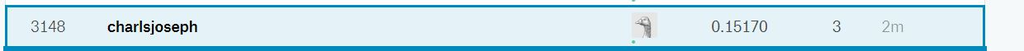

Kaggle Score